# Part II - Loan Data from Prosper

## by Kelton Cumbe

## Investigation Overview

This data set contains 113,937 loans with 81 variables on each loan, including loan amount, borrower rate (or interest rate), current loan status, borrower income, and many others. In this project we will be exploring a dataset known as the Prosper Loan Dataset. The Prosper Loan Dataset is a dataset that contains data of the loan platform known as '[Prosper](https://www.prosper.com/)'.

## Dataset Overview

The present dataset are composed of 81 columns variables, and 113937 row records of loans data. Here we can find a table mostly composed of following data structure, such as float and int datatypes, in resume, we can find: 3 booleans, 11 int, 17 objects and 50 float.

Due to the exploration task, these datasets were further divided into a smaller dataframe called `acquired_values` containing just the variables of interest for our analysis. The `acquired_values` consists of 11 variables of which 7 are float, 1 is an int and 3 are of object type.

## Comparsion Relation between Borrower's Rate & Borrower's APR in Resume

We can assume, according to the information below, that the data visualized is positively correlated, for each LoanStatus category. This is because the borrower's APR increases as the borrower's rate increases.

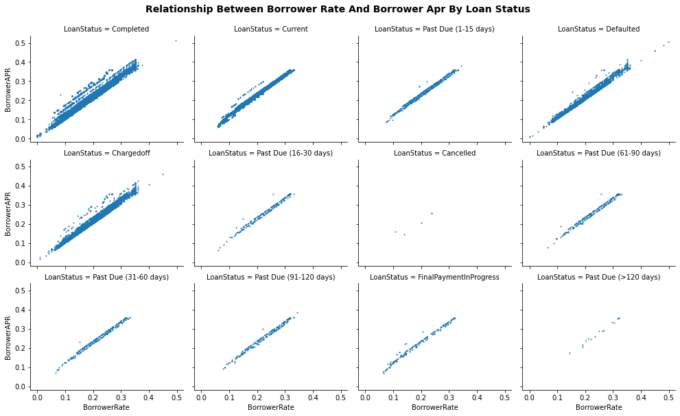

## Preview Loan Status in Percentage

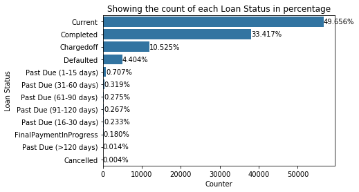

## Preview Distribution of Borrower's Rate

In this third presentation, we see that the Borrower Rate is seen to be unimodal and slightly skewed to the right. When the bins were adjusted, we discovered some high peaks on the right side of our distribution.

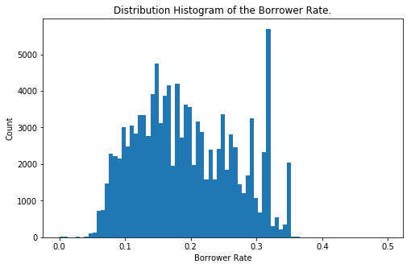

## Comparsion Between Loan Status & Borrower's Rate

Now we have our fourth presentation, where we have a violin plot, showing a lower median of values below 20% borrower rate for Completed, Current and FinalPaymentInProgress Statuses, and for the rest of the categories it has a higher median which is approximately 25%. And it can be concluded from this that the positive results of the LoanStatus for Completed, FinalPaymentInProgress, for example, are characterized with a lower rate of the borrower, while we have negative results for example for the Defaulted, Past Due, which are characterized with a higher rate of the borrower.

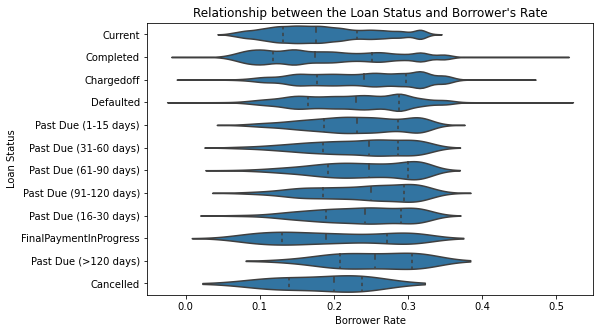

## Corrolation Between Borrower's Rate & Borrower's APR

We have reached the end of our presentation... And in this part, we have illustrated below, the scatter plot between the BorrowerRate and BorrowerAPR, where it shows the positive correlation between the variables I mentioned. And with that we can conclude that, as the BorrowerRate increases the BorrowerAPR increases as well.

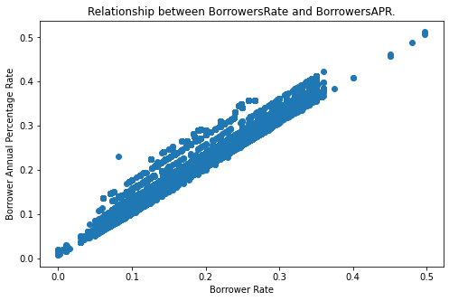